# STAT380 Final Project

Jonathan Bryant, Natalie Chow, Yearin Kim, Yeji Park

December 12, 2022

```r
rm(list = ls())
library(tidyverse)
library(fastDummies)
library(rpart)
library(rattle)
library(caret)
library(randomForest)
library(e1071)
library(glmnet)
```

#### Import Data

```r
COD_p1 <- read_csv("C:/Users/kzy51/Desktop/CODGames_p1_380.csv")
COD_p2 <- read_csv("C:/Users/kzy51/Desktop/CODGames_p2_380.csv")
CODGameModes <- read_csv("C:/Users/kzy51/Desktop/CODGameModes.csv")
```

### Task 1

**Research Question:** Which game mode is most likely to reach the score limit?

The data for this project consists of three separate datasets, which were used to determine the game mode that was most likely to reach the score limit. Each player’s dataset was imported into their own data frames, and then combined using the code below. A new variable `Player` was added to each data frame before combining in case distinguishing each player became relevant for future analysis.

#### Preparing the data

```r
# Create dataset for each player
COD_p1 <-
  COD_p1 %>%
  mutate(Player = "p1")

COD_p2 <-
  COD_p2 %>%
  mutate(Player = "p2")

# Aggregate player data for analysis
player_data <- rbind(COD_p1, COD_p2)
```

#### Clean GameType column values

The values for GameType (mode) were slightly different between the two players. Player 2 included “HC” in front of the basic game type. This HC likely stands for “Hardcore”, a variant of the standard or basic game modes (Liebl, 2022). For this analysis, the focus is on the basic types, so differentiating between `HC-TDM` and `TDM` would negatively impact the accuracy. To fix this, we added a new variable to `player_data` that contained only the basic data type.

```r
unique(player_data$GameType)
```

```
## [1] "HC - TDM"            "HC - Kill Confirmed" "HC - Hardpoint"
## [4] "HC - Domination"     "TDM"                 "Hardpoint"
## [7] "Kill Confirmed"      "Domination"
```

```r
# Create standard names for gametype
gametype <-
  player_data %>%
  mutate(TDM = ifelse(GameType == "HC - TDM" | GameType == "TDM", "TDM", NA),
         HP = ifelse(GameType == "HC - Hardpoint" | GameType == "Hardpoint", "Hardpoint", NA),
         KC = ifelse(GameType == "HC - Kill Confirmed" | GameType == "Kill Confirmed", "Kill Confirmed", NA),
         DOM = ifelse(GameType == "HC - Domination" | GameType == "Domination", "Domination", NA)) %>%
  select(TDM, HP, KC, DOM)

# Combine all columns into one variable
gametype <-
  coalesce(gametype$TDM, gametype$HP, gametype$KC, gametype$DOM)

# Make gametype a dataframe
gametype <- data.frame(gametype)

# Rename gametype as mode to make join easier
gametype <-
  gametype %>%
  rename("Mode" = "gametype")

# Adding Mode to player_data
player_data <-
  cbind(player_data, gametype)
```

#### Joining to determine the score limit

```r
player_data <-
  player_data %>%
  inner_join(CODGameModes %>% select(Mode, ScoreLimit),
             by = c("Mode" = "Mode"))
```

When analyzing the data for each task, a significant issue was misspellings and inconsistent categorical data levels. These inconsistencies cause two main problems, duplication of categorical levels and compatibility with different packages.

The misspellings and other inconsistencies in some variables need to be fixed due to the nature of the research questions. When creating dummy variables, these misspelled values would become their own variable, changing the model. By correcting the values, we lower the overall number of variables (reduces computational complexity) and produce more accurate models.

Some categorical variables’ values became an issue for specific packages. The randomforest package (randomForest) used in Task 3 was not able to utilize variables that contained back ticks. These backticks are used automatically when dummy variables were created from categorical variables such as `PrimaryWeapon`. The fastDummies package took invalid variable names such as AK-47 and changed it to `AK-47`, which is generally seen as a valid name for R. Unfortunately, the randomForest package cannot handle these variable names so the values needed to be corrected before turned into dummy/indicator variables.

In the code below, the names of the variables in the data are not actually changed, but a variable with corrected values is added to the dataset. These variables are designated with a “c_” to distinguish them from the ones found in the original dataset. We chose not to replace the incorrect names because we may be interested in utilizing them for other research questions in the future.

#### Fix misspellings in Map1, Map2, MapVote, Primary Weapon and XPType

```r
## Find unique levels in Maps
map_corrector <- unique(c(player_data$Map1, player_data$Map2, player_data$Choice))

## Make ma_corrector a tibble
map_corrector <- as_tibble(map_corrector)

## List of correct map names
correct_map_names <- c("Amerika", "Armada", "Apocolypse", "Cartel","Crossroads", "Checkmate", "Collateral", "Deisel", "Deprogram", "Echelon", "Express", "Garrison", "Hijacked", "Jungle", "Miami", "Moscow", "Nuketown", "Raid", "Rush", "Satellite", "Slums", "Standoff",  "The", "WMD", "Yamanutau", "Zoo")

## Make a tibble
correct_map_names <- as_tibble(correct_map_names)

## Create key to match possible misspelled names against
correct_map_names <-
  correct_map_names %>%
  rename(MapNames = value) %>%
  # Majority of matching is done by first 3 letters of the maps name
  mutate(first_three = str_to_lower(str_extract(string = MapNames, pattern = "([:alpha:]{3})"))) %>%
  # Following rows are outliers
  add_row(MapNames = "Deisel", first_three = "die") %>%
  add_row(MapNames = "Drive_In", first_three = "dri") %>%
  add_row(MapNames = "Raid", first_three = "ria") %>%
  add_row(MapNames = "Rush", first_three = "rua") %>%
  add_row(MapNames = "Armada", first_three = "amr")

## Prep MapNames to match against correct names
map_corrector <-
  map_corrector %>%
  rename(MapNames = value) %>%
  arrange(MapNames) %>%
  mutate(main_map_name = str_extract(string = MapNames, pattern = "([:alpha:]*)"),
         first_three = str_to_lower(str_extract(string = MapNames, pattern = "([:alpha:]{3})")),
         second_name = str_extract(string = MapNames, pattern = "(?<=[:space:]{1})([:alpha:]*)")) %>%
  #Join to make matches
  left_join(correct_map_names, by = ("first_three" = "first_three")) %>%
  rename(corrected_1st_name = MapNames.y)

## Make sure second portion of the name is correctly assigned
map_corrector <-
  map_corrector %>%
  mutate(corrected_2nd_name = ifelse(grepl("[rR]",map_corrector$second_name), "Strike", ifelse(grepl("[P]", map_corrector$second_name), "Pines", ifelse(grepl("[-]", map_corrector$second_name), "_in", ifelse(grepl("[Hall]", map_corrector$second_name), "'64_Halloween", ifelse(grepl("['64]", map_corrector$second_name), "_'64", NA))))),
         # Final correct names are saved as c_map
         c_map = ifelse(is.na(corrected_2nd_name) == TRUE, corrected_1st_name, paste(corrected_1st_name, corrected_2nd_name, sep = "_")))
```

```r
# Add corrected names back to player_data
player_data <-
  player_data %>%
  left_join(map_corrector %>% select(MapNames.x, c_map), by = c("Map1" = "MapNames.x")) %>%
  rename("c_Map1" = "c_map") %>%
  left_join(map_corrector %>% select(MapNames.x, c_map), by = c("Map2" = "MapNames.x")) %>%
  rename("c_Map2" = "c_map") %>%
  left_join(map_corrector %>% select(MapNames.x, c_map), by = c("Choice" = "MapNames.x")) %>%
  rename("c_Choice" = "c_map")
```

```r
# Fix Primary Weapon Names
weapon_names <- as_tibble(unique(c(player_data$PrimaryWeapon)))

weapon_names <-
  weapon_names %>%
  rename(weapon_names = value)

corrected_names <- c("M16", "MP5", "AK_47", "Krig_6", "QBZ_83", "Pellington_703", "FFAR_1", "Type_63", "MG_82", "XM4", "LC_10", NA, "M60", "ShadowHunter", "FARA_83", "Milano", "DMR_14", "Pellington", "KSP_14", "Groza", "AUG", "Milano_821", "Magnum", "RPD")

weapon_names <- cbind(weapon_names, corrected_names)

player_data <-
  player_data %>%
  left_join(weapon_names, by = c("PrimaryWeapon" = "corrected_names")) %>%
  rename(c_PrimaryWeapon = weapon_names)
```

```r
# Fix XP types
xp_types <- c("10% Boost", "Double XP + 10%")
corrected_xp <- c("10_Boost", "Double_XP_Plus_10")

XP <- as_tibble(cbind(xp_types, corrected_xp))

player_data <-
  player_data %>%
  left_join(XP, by = c("XPType" = "xp_types")) %>%
  rename(c_XPTypes = corrected_xp)
```

#### Calculating success percentage of hitting score limit

The `Result` variable contained the score for both teams, which is used to see if either team reached the score limit in each match. Even though the actual scores for each team are numeric values, `Result` is a character due to `-` between the scores. We isolated the player (team) and enemy (team) scores by using regex to extract the numerical values in series from the beginning (player score) and also from the end (enemy score). These scores are added as new variables to `player_data`.

```r
# Splitting the result variable into player score or enemy score
player_data <-
  player_data %>%
  mutate(player_score = str_extract(string = Result, pattern = "(\\d*)"),
         enemy_score = str_extract(string = Result, pattern = "(\\d*$)"),
         player_score = as.numeric(player_score),
         enemy_score = as.numeric(enemy_score))

## Fixed to show either player or enemy score hit score limit
player_data <-
  player_data %>%
  mutate(reached_score_limit = ifelse(player_score == ScoreLimit, 1, ifelse(enemy_score == ScoreLimit,1,0)))

# Calculate success percentage
df <-
  player_data %>%
  group_by(Mode) %>%
  summarize(total_games = n(),
          rsl_total = sum(reached_score_limit, na.rm = TRUE),
          rsl_percent = rsl_total/total_games) %>%
  arrange(desc(rsl_percent))
df
```

```
## # A tibble: 4 × 4
##   Mode           total_games rsl_total rsl_percent
##   <chr>                <int>     <dbl>       <dbl>
## 1 Domination              14        14       1
## 2 Hardpoint              267       251       0.940
## 3 TDM                    537       429       0.799
## 4 Kill Confirmed          21        16       0.762
```

#### Data Visualization of the success percentage for each game mode

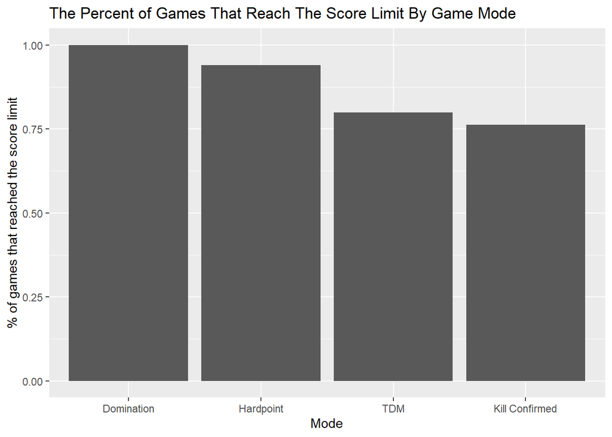

```r
ggplot(data = df, mapping = aes(x = reorder(Mode, -rsl_percent), y = rsl_percent)) +
  geom_bar(stat="identity") +
  labs(x = "Mode", y = "% of games that reached the score limit", title = "The Percent of Games That Reach The Score Limit By Game Mode")
```

After separating the player and enemy scores, we compared each team’s score to the limit for each map. Using this result, we calculated the success percentage for each game mode. Based on the graph above, the Domination game mode is most likely to reach the score limit because it has the highest success percentage of 100%.

### Task 2

**Research Question:** Build a model for modeling the TotalXP variable. Which predictors are associated with TotalXP? What is the relationship between one of the predictors and TotalXP?

#### a. Which predictors are associated with the TotalXP?

We used a linear regression with backwards elimination to find the predictors of TotalXP. Since there were 38 different variables or features of this dataset, backwards elimination was used to select the appropriate variables for this model. One issue that needed to be resolved before building the model was NA values. The first section of the code below looks at how complete each variable is within the dataset. There were four variables that only contained NA values and thirteen more that had less than 80% complete. These seventeen variables were removed from the dataset as they likely had little to no impact on the model.

Based on our understanding of the game, we felt that the result of the match was likely associated to the TotalXP. Since `Result` contained only character values, we created a dummy variable, `won_match` from `player_score` and `enemy_score`. Lastly, we created dummy variables for the remaining categorical variables and removed the variables with low completeness or ones that caused issues with building the model (such as causing perfect separation).

```r
# Find variables with high percent of NAs. We will remove variables with <=20% completion
num_na <- sapply(player_data, function(x) sum(is.na(x)))
na_per_column <- data.frame(num_na)
na_per_column <-
  na_per_column %>%
  mutate(perc_missing = format(round((num_na/nrow(player_data)),2))) %>%
  arrange(desc(perc_missing))
head(na_per_column, 10)
```

```
##            num_na perc_missing
## Diffuses      839         1.00
## Plants        839         1.00
## Detonates     839         1.00
## Deposits      839         1.00
## Confirms      819         0.98
## Denies        819         0.98
## Captures      821         0.98
## Objectives    801         0.95
## Time_Sec      586         0.70
## Time_Min      586         0.70
```

```r
# Instead of result, add if they win
player_data <-
  player_data %>%
  mutate(won_match = ifelse(player_score > enemy_score, 1, 0))

# Select variables with only low percent of NA and create dummy variables for categorical variables
player_data_sub <-
  player_data %>%
  select(c(-Diffuses, -Plants, -Detonates, -Deposits, -Map1, -Map2, -Choice, -MapVote, -Date, -Result, -GameType, -Confirms, -Denies, -Captures, -Objectives, -Time_Sec, -Time_Min, -ObjectiveKills, -c_Map1, -c_Map2, -PrimaryWeapon, -XPType)) %>%
  dummy_cols(select_columns = c("FullPartial", "PrimaryWeapon", "XPType", "Player", "Mode", "c_Choice", "DidPlayerVote", "c_PrimaryWeapon", "c_XPTypes"), remove_selected_columns = TRUE, ignore_na = TRUE)

player_data_sub <-
  player_data_sub %>%
  rename(Mode_Kill_Confirmed = `Mode_Kill Confirmed`)
```

```r
# Use backwards elimination to determine the appropriate variables
full_model <- glm(TotalXP ~ . ,
                  family = gaussian,
                  data = player_data_sub)

model_task2 <- stats::step(object = full_model,
            scope = list(upper = full_model),
            data = player_data_sub,
            direction = "backward")
```

The predictors associated with TotalXP are Eliminations, Score, ScoreLimit, player_score, enemy_score, won_match, Mode_Domination, c_Choice_Checkmate, c_Choice_Crossroads_Strike, c_Choice_Miami_Strike, c_Choice_Rush, c_Choice_The_Pines, c_PrimaryWeapon_AUG, c_PrimaryWeapon_Groza, _PrimaryWeapon_M16, c_PrimaryWeapon_M60, c_PrimaryWeapon_Magnum, c_PrimaryWeapon_Milano, c_PrimaryWeapon_MP5, c_PrimaryWeapon_Pellington, c_PrimaryWeapon_RPD and c_XPTypes_10_Boost.

### b. Explain the relationship between the predictor and TotalXP

```r
summary(model_task2)
```

```
##
## Call:
## glm(formula = TotalXP ~ Eliminations + Score + ScoreLimit + player_score +
##     enemy_score + won_match + Mode_Domination + c_Choice_Checkmate +
##     c_Choice_Crossroads_Strike + c_Choice_Miami_Strike + c_Choice_Rush +
##     c_Choice_The_Pines + c_PrimaryWeapon_AUG + c_PrimaryWeapon_Groza +
##     c_PrimaryWeapon_M16 + c_PrimaryWeapon_M60 + c_PrimaryWeapon_Magnum +
##     c_PrimaryWeapon_Milano + c_PrimaryWeapon_MP5 + c_PrimaryWeapon_Pellington +
##     c_PrimaryWeapon_RPD + c_XPTypes_10_Boost, family = gaussian,
##     data = player_data_sub)
##
## Deviance Residuals:
##      Min        1Q    Median        3Q       Max
## -10143.8   -2048.8    -368.5    1658.3   19144.7
##
## Coefficients:
##                              Estimate Std. Error t value Pr(>|t|)
## (Intercept)                12882.7748  2076.2148   6.205 1.34e-09 ***
## Eliminations                 352.8705    45.7789   7.708 9.74e-14 ***
## Score                          0.5847     0.2323   2.517 0.012221 *
## ScoreLimit                   -20.6947     7.9095  -2.616 0.009214 **
## player_score                  18.7395     6.4410   2.909 0.003818 **
## enemy_score                   16.8151     5.4625   3.078 0.002222 **
## won_match                   1580.8603   447.8409   3.530 0.000463 ***
## Mode_Domination             1849.7522  1030.7348   1.795 0.073455 .
## c_Choice_Checkmate          2577.1400   787.1603   3.274 0.001150 **
## c_Choice_Crossroads_Strike -2942.6992   693.8199  -4.241 2.75e-05 ***
## c_Choice_Miami_Strike      -2989.5918   862.0983  -3.468 0.000580 ***
## c_Choice_Rush              -1449.6128   890.7137  -1.627 0.104405
## c_Choice_The_Pines          1636.8853   748.6664   2.186 0.029351 *
## c_PrimaryWeapon_AUG        -3929.4983  2094.4641  -1.876 0.061347 .
## c_PrimaryWeapon_Groza      -5739.6772  2055.1989  -2.793 0.005471 **
## c_PrimaryWeapon_M16        -5785.4640  2051.4585  -2.820 0.005033 **
## c_PrimaryWeapon_M60        -5061.8669  2058.2894  -2.459 0.014335 *
## c_PrimaryWeapon_Magnum     -6676.1813  2876.9892  -2.321 0.020801 *
## c_PrimaryWeapon_Milano     -3771.8319  2168.2138  -1.740 0.082679 .
## c_PrimaryWeapon_MP5        -6336.0191  2068.1757  -3.064 0.002331 **
## c_PrimaryWeapon_Pellington -5426.5787  2088.6033  -2.598 0.009709 **
## c_PrimaryWeapon_RPD        -5650.7947  2065.3409  -2.736 0.006489 **
## c_XPTypes_10_Boost         -6756.4209   405.1193 -16.678  < 2e-16 ***
## ---
## Signif. codes:  0 '***' 0.001 '**' 0.01 '*' 0.05 '.' 0.1 ' ' 1
##
## (Dispersion parameter for gaussian family taken to be 11813999)
##
##     Null deviance: 2.0219e+10  on 432  degrees of freedom
## Residual deviance: 4.8437e+09  on 410  degrees of freedom
##   (406 observations deleted due to missingness)
## AIC: 8304.5
##
## Number of Fisher Scoring iterations: 2
```

### Task 3

**Question:** Among the 3 different classification algorithms we used, which can more accurately classify if the player won or lost the game based on the match attributes?

The three classification algorithms used were logistic regression (with backwards elimination), random forest, and support machine vector. To more accurately compare the models, we used the same train/test datasets across all three models. Before splitting the data, we standardized the data since SVM is based on distance. Standardizing or scaling the data should not affect the accuracy of the models.

#### Preparing the dataset

```r
# Remove variables directly related to winning
player_data_sub_task3 <-
  player_data_sub %>%
  select(c(-player_score, -enemy_score, -Score))  # These directly predict if we are going to win or not (perfect separation)

# Remove NAs
player_data_sub_task3 <-
  player_data_sub_task3 %>%
  na.omit()

# Scale the data
xvars <- colnames(player_data_sub_task3)

xvars <- xvars[!xvars %in% c('won_match')]

player_data_sub_task3[, xvars] <- scale(player_data_sub_task3[, xvars],center = TRUE, scale = TRUE)

# Train/Test split
set.seed(123)
train_ind <- sample(1:nrow(player_data_sub_task3), floor(0.8 * nrow(player_data_sub_task3)))
set.seed(NULL)

Train <- player_data_sub_task3[train_ind, ]
Test <- player_data_sub_task3[-train_ind, ]
```

#### Method 1: Logistic Regression

```r
# Use logistic regression
full_model3 <- glm(as.factor(won_match) ~.,
             family = binomial,
             data = Train)

model_task3 <- stats::step(full_model3, # This isn't needed for backwards induction
             data = Train,
             direction = "backward")
```

```r
summary(model_task3)
```

```
##
## Call:
## glm(formula = as.factor(won_match) ~ Deaths + TotalXP + ScoreLimit +
##     FullPartial_Full + Player_p1 + c_Choice_Collateral + c_Choice_Collateral_Strike +
##     c_Choice_Deprogram + c_Choice_Hijacked + c_Choice_Nuketown +
##     c_Choice_Rush + c_PrimaryWeapon_AUG + c_PrimaryWeapon_Groza +
##     c_PrimaryWeapon_M16 + c_PrimaryWeapon_M60 + c_PrimaryWeapon_Milano +
##     c_PrimaryWeapon_MP5 + c_PrimaryWeapon_Pellington + c_PrimaryWeapon_RPD +
##     c_PrimaryWeapon_ShadowHunter + c_XPTypes_10_Boost, family = binomial,
##     data = Train)
##
## Deviance Residuals:
##      Min        1Q    Median        3Q       Max
## -2.52550  -0.92129   0.07947   0.88402   2.24728
##
## Coefficients:
##                               Estimate Std. Error z value Pr(>|z|)
## (Intercept)                    0.05466   17.79534   0.003  0.99755
## Deaths                        -1.21237    0.18861  -6.428 1.29e-10 ***
## TotalXP                        0.99229    0.21171   4.687 2.77e-06 ***
## ScoreLimit                     0.49543    0.18673   2.653  0.00797 **
## FullPartial_Full               0.34691    0.14676   2.364  0.01809 *
## Player_p1                     -0.39934    0.18210  -2.193  0.02831 *
## c_Choice_Collateral           -1.39372  139.52204  -0.010  0.99203
## c_Choice_Collateral_Strike    -0.26192    0.14515  -1.804  0.07116 .
## c_Choice_Deprogram             0.18947    0.12192   1.554  0.12017
## c_Choice_Hijacked              0.19320    0.12484   1.548  0.12170
## c_Choice_Nuketown              0.20136    0.14049   1.433  0.15178
## c_Choice_Rush                  0.46519    0.16234   2.866  0.00416 **
## c_PrimaryWeapon_AUG           -4.91986  324.52631  -0.015  0.98790
## c_PrimaryWeapon_Groza         -6.78635  431.51520  -0.016  0.98745
## c_PrimaryWeapon_M16           -6.53399  433.27290  -0.015  0.98797
## c_PrimaryWeapon_M60           -5.13573  339.86949  -0.015  0.98794
## c_PrimaryWeapon_Milano        -3.57232  228.44732  -0.016  0.98752
## c_PrimaryWeapon_MP5           -5.24060  330.80372  -0.016  0.98736
## c_PrimaryWeapon_Pellington    -4.39235  293.61233  -0.015  0.98806
## c_PrimaryWeapon_RPD           -5.22507  330.80372  -0.016  0.98740
## c_PrimaryWeapon_ShadowHunter  -1.49680  126.10822  -0.012  0.99053
## c_XPTypes_10_Boost             0.53413    0.19315   2.765  0.00569 **
## ---
## Signif. codes:  0 '***' 0.001 '**' 0.01 '*' 0.05 '.' 0.1 ' ' 1
##
## (Dispersion parameter for binomial family taken to be 1)
##
##     Null deviance: 479.47  on 345  degrees of freedom
## Residual deviance: 366.77  on 324  degrees of freedom
## AIC: 410.77
##
## Number of Fisher Scoring iterations: 15
```

```r
thresholds <- as_tibble(seq(0,1, by = 0.01))

names(thresholds) <- "thresholds"

task3 <- as_tibble(Test$won_match)
names(task3) <- "won_match"

pred_prob <- predict(model_task3, newdata = Test, type = "response")

task3 <- cbind(task3, pred_prob)

accuracy <- data.frame(rep(NA, 101))

for (i in 1:nrow(accuracy)){
  probs <-
    task3 %>%
    mutate(threshold = thresholds$thresholds[i])
  probs <-
    probs %>%
    mutate(predicted = ifelse(pred_prob > threshold, "win", "loss"),
           TPmatch = ifelse(won_match == 1 & predicted == "win", 1 ,0),
           FNmatch = ifelse(won_match == 1 & predicted == "loss", 1, 0),
           TNmatch = ifelse(won_match == 0 & predicted == "loss", 1, 0),
           FPmatch = ifelse(won_match == 0 & predicted == "win", 1, 0)) %>%
    summarize(TP = sum(TPmatch),
              FN = sum(FNmatch),
              TN = sum(TNmatch),
              FP = sum(FPmatch)) %>%
    summarize(ACC = (TP+TN)/(TP + FP + TN + FN))

  accuracy[i, ] <- probs

}
thresholds <- cbind(thresholds, accuracy)

threshold_ind <- which.max(thresholds$rep.NA..101.)
threshold_ind
```

```
## [1] 38
```

```r
threshold <- thresholds[38, 1]

pred_won <- ifelse(pred_prob > threshold, 1, 0)

# Confusion Matrix
confusionMatrix(data = as.factor(pred_won), positive = "1", reference = as.factor(Test$won_match))
```

```
## Confusion Matrix and Statistics
##
##           Reference
## Prediction  0  1
##          0 24 12
##          1 16 35
##
##                Accuracy : 0.6782
##                  95% CI : (0.5694, 0.7744)
##     No Information Rate : 0.5402
##     P-Value [Acc > NIR] : 0.006175
##
##                   Kappa : 0.3473
##
##  Mcnemar's Test P-Value : 0.570750
##
##             Sensitivity : 0.7447
##             Specificity : 0.6000
##          Pos Pred Value : 0.6863
##          Neg Pred Value : 0.6667
##              Prevalence : 0.5402
##          Detection Rate : 0.4023
##    Detection Prevalence : 0.5862
##       Balanced Accuracy : 0.6723
##
##        'Positive' Class : 1
##
```

For Method 1, we used backward elimination for logistic regression to select the predictors used in the model. Using the new model, we created predicted values based on the `Test` dataset. To determine if the predicted values should be classified as won or lost, a threshold between the two needs to be established. We used a loop to check the threshold values from 0 to 1 using steps of 0.01 to determine the threshold that would produce the best accuracy. For this logistic model, we were able to accuracy classify 67.8 percent of the matches.

### Method 2: Random Forest

```r
set.seed(123)
rf <- randomForest(as.factor(won_match) ~ ., data = Train, importance = TRUE, na.action = na.omit)
set.seed(NULL)
```

```r
## Obtain Predicted classes
pred_surv <- predict(rf, newdata = Test, type = "class")
head(pred_surv)
```

```
##  1  3  6  9 12 15
##  0  1  0  1  1  0
## Levels: 0 1
```

```r
## Obtain Confusion matrix and calculate accuracy

#Confusion Matrix
table(pred_surv, Test$won_match)
```

```
##
## pred_surv  0  1
##         0 26 21
##         1 14 26
```

```r
#Calculate accuracy
mean(pred_surv == Test$won_match)
```

```
## [1] 0.5977011
```

For Method 2, we used random forest to calculate the predicted probabilities in order to create a confusion matrix, in which we got an accuracy of 0.5977.

### Method 3: SVM

```r
set.seed(1)
tuned_cost <- tune.svm(won_match ~.,
                       data = Train,
                       kernel = "linear",
                       cost = seq(0.01, 1, by = 0.01),
                       scale = FALSE)
set.seed(NULL)
summary(tuned_cost)
```

[output not shown]

```r
set.seed(1)
svm_model <- svm(won_match ~.,
                 data = Train,
                 type = "C-classification",
                 kernel = "linear",
                 cost = 0.2702391,
                 scale = FALSE)

set.seed(1)
pred_prob3 <- predict(svm_model, Test)
prob3 <- mean(pred_prob3 == Test$won_match)

prob3
```

```
## [1] 0.6321839
```

### Conclusion for Task 3

Among the 3 classification methods, the logistic regression (Method 1) resulted in the highest accuracy for classifying whether the player won or lost the game. The logistic regression was predicted 67.8 percent of matches, followed by SVM with 63% and random forest with roughly 59.7%. Using the same `Train`/`Test` datasets allowed us to directly compare the accuracy between each model. It is possible in the future we could tune the random forest and SVM models to produce more accurate results.

### References

Leibl, M. (2022). *Where is Call of Duty: Modern Warfare’s Hardcore Mode?*. AppTrigger. https://apptrigger.com/2022/10/28/call-duty-modern-warfare-disable-crossplay/

Guyon, I. & Elisseef, A. (2003). An Introduction to Variable and Feature Selection. *Journal of Machine Learning Research, 3(7-8), 1157–1182*. https://doi.org/10.1162/153244303322753616